# Прогнозирование заказов такси

### Тренды и сезонность

**Декомпозиция - 1 час**

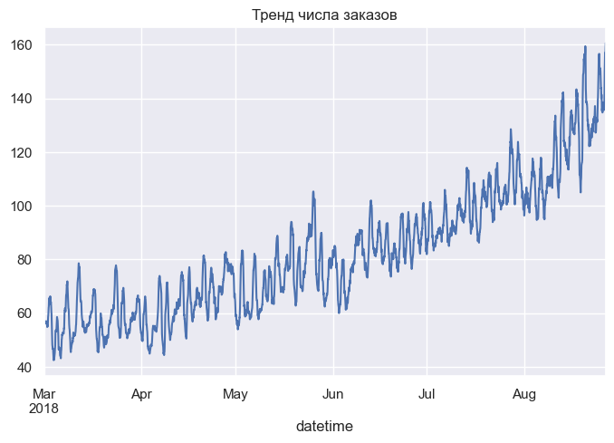

```python
decomposed_1h_sum = seasonal_decompose(df_print['num_orders'])
(
    decomposed_1h_sum.trend['2018-03-01':'2018-08-26']
        .plot(title='Тренд числа заказов')
)
plt.show()
```

Тренд восходящий, минимумы и максимумы повышаются.

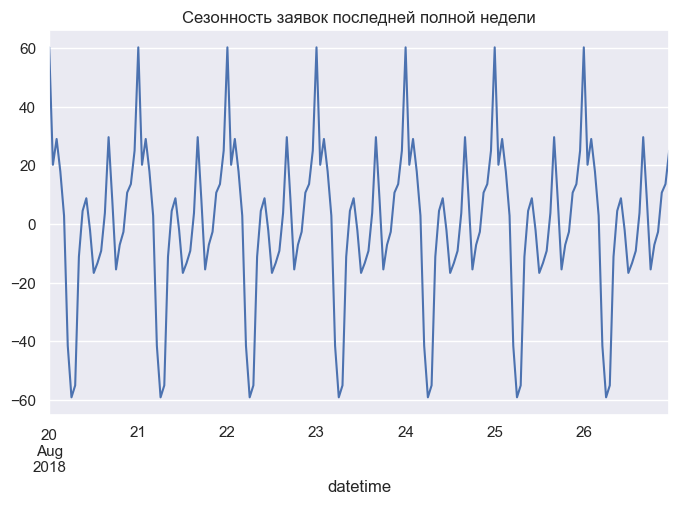

```python
(
    decomposed_1h_sum.seasonal['2018-08-20':'2018-08-26']
    .plot(title='Сезонность заявок последней полной недели')
)
plt.show()
```

Дневная сезонность подтверждается, рассмотрим в разрезе 1 дня. Подозреваю, что данные были синтезированы, так как выходные должны отличаться от будней.

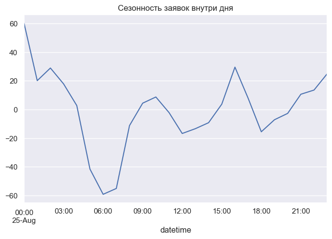

```python
(
    decomposed_1h_sum.seasonal['2018-08-25':'2018-08-25']
    .plot(title='Сезонность заявок внутри дня')
)
plt.show()
```

Внутри дня - спад заказов с полуночи до утра, всплеск количества заказов:

- c 01-00 до 02-00. Клиенты возвращаются домой.
- с 06-20 до 10-00. Клиенты едут на работу и совершают деловые поездки.
- с 12-00 до 17-00. Снова возрастает деловая активность, а так же влияет обеденное время.
- с 18-00 до 00-00. Конец рабочего дня, поездки по личным делам.

Затем дневная сезонность падает, до следующего утра.

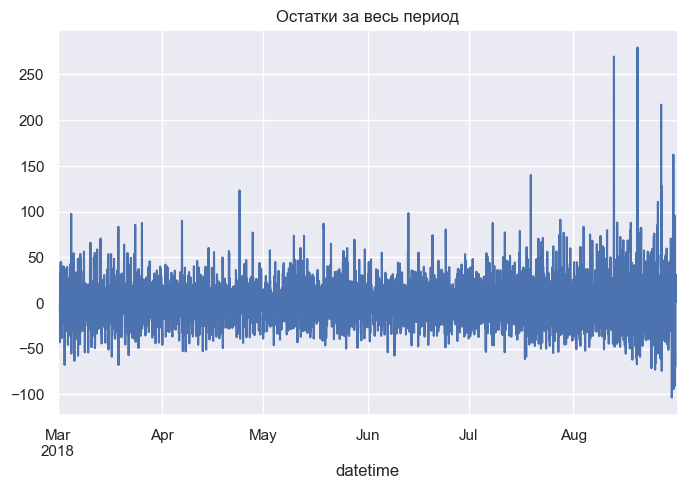

```python
(
    decomposed_1h_sum.resid['2018-03-01':'2018-08-31']
    .plot(title='Остатки за весь период')
)
plt.show()
```

Остатки неоднородные, нарушена гомоскедастичность. На графике заметны аномалии, перед 01 сентября аномалии усиливаются. Возможно здесь есть паттерны, которые можно исследовать имея данные за несколько лет.

**Декомпозиция - 1 день**

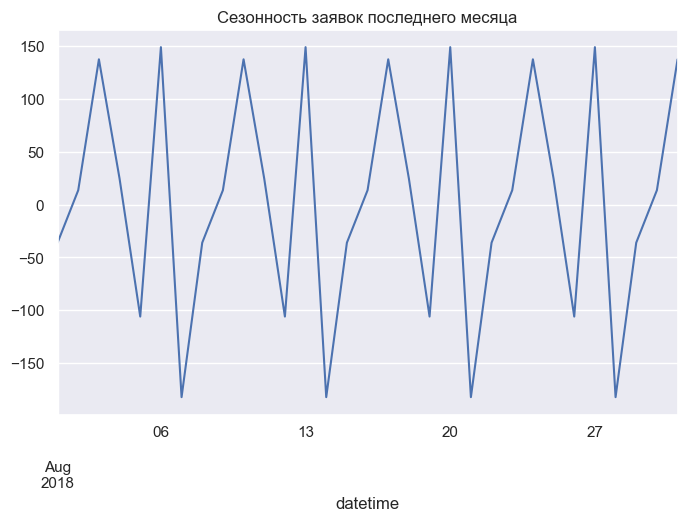

```python
decomposed_1d_sum = seasonal_decompose(df_print['num_orders'].resample('1D').sum())
(
    decomposed_1d_sum.seasonal['2018-08-01':'2018-08-31']
    .plot(title='Сезонность заявок последнего месяца')
)
plt.show()
```

Недельная сезонность подтверждается, рассмотрим в разрезе 1 недели.

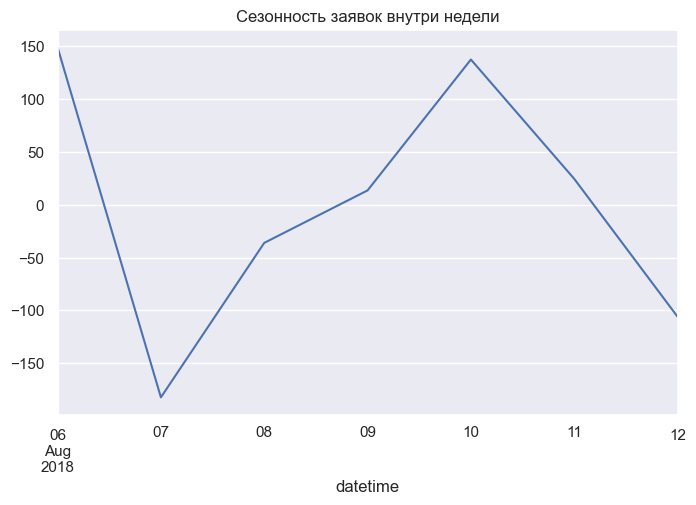

```python
(
    decomposed_1d_sum.seasonal['2018-08-06':'2018-08-12']
    .plot(title='Сезонность заявок внутри недели')
)
plt.show()
```

```python
del df_print
```

Внутри недели:

- Понедельник. Резкий рост количества заказов.
- Вторник. Самый невостребованный день по заказам.
- Среда-Пятница. Планомерный рост числа заказов.
- Суббота-Воскресенье. Планомерное снижение числа заказов.

**Вывод** Учитывая сезонность внутри недели и дня, генерируем скользящие признаки:

- Трехчасовые
- Суточные
- Недельные

По графику видно, что данные по скользящей средней распределены нормально. С июля увеличивается скользящее стандартное отклонение, это может свидетельствовать о повышенном спросе на услуги такси, что может быть связано с началом завершительного периода сезона отпусков или ростом компании.

Вышесказанное означает, что прогнозировать по существующим данным - можно, временные ряды - стационарные.

К содержанию

### Добавление признаков

**Определение тактики добавления признаков**

Кодирование признаков, связанных с датой и временем (например, месяц, дата, день недели), является важной частью предобработки данных для временных рядов. Эффективное кодирование может улучшить качество модели и её способность выявлять закономерности в данных. Рассмотрим различные способы кодирования этих признаков и их влияние на модель.

1. **Месяц (Month)**.

*Способы кодирования:*

- **Прямое кодирование (Direct Encoding)**: Присвоение уникального числового значения каждому месяцу (например, 1 для января, 2 для февраля и так далее). Этот метод может привести к нежелательным отношениям между месяцами (например, январь < февраль), что не всегда соответствует реальности.
- **One-Hot Encoding**: Создание бинарных столбцов для каждого месяца, принимающих значение 1 или 0 в зависимости от месяца. Этот метод избегает нежелательных отношений и широко используется.

*Влияние на модель:* Выбор между прямым кодированием и One-Hot Encoding зависит от особенностей данных и модели. One-Hot Encoding часто предпочтителен, так как он не создает искусственные отношения между месяцами.

2. **Дата (Date)**

*Способы кодирования:*

- **День в году (Day of Year)**: Присвоение числового значения от 1 до 365 (или 366 для високосного года) для каждой даты в году.
- **День месяца (Day of Month)**: Присвоение числового значения от 1 до 31 для каждого дня месяца.
- **День недели (Day of Week)**: Присвоение числового значения от 0 до 6 (или от 1 до 7) для каждого дня недели.

*Влияние на модель:* Корректное кодирование даты может помочь модели учиться на закономерностях, связанных с конкретными днями, неделями или месяцами.

3. **День недели (Day of Week)**

*Способы кодирования:*

- **Прямое кодирование (Direct Encoding)**: Присвоение уникального числового значения каждому дню недели (например, 0 для воскресенья, 1 для понедельника и так далее).
- **One-Hot Encoding**: Создание бинарных столбцов для каждого дня недели.

*Влияние на модель:* Кодирование дня недели позволяет модели учиться на возможных паттернах, зависящих от конкретного дня недели.

**Выводы:**

- One-Hot Encoding часто предпочтителен для кодирования месяца и дня недели, так как он избегает искусственных отношений между категориями.
- Выбор между **MEstimateEncoder** и **One-Hot Encoding** для кодирования категориальных признаков таких, как месяц и день недели, зависит от контекста, данных и модели, которую мы планируем использовать. Мы не можем дать четкий ответ - достаточно ли наблюдений, чтобы модель не переобучилась используя - MEstimateEncoder. **Необходимо - пробовать.** В учебном проекте, при достижении необходимого качества модели, изыскания будут прекращены.

Для даты и времени выбираем **Числа с MEstimateEncoder**: - Day of Week - Hour period (Часовой промежуток в сутках, с шагом 3ч.)

```python
# Добавление признаков в датасет, проводим только векторизацию.
def make_features(data, max_lag):
    # Лист календаря
    data['day_of_week'] = data.index.dayofweek
    data['hour'] = data.index.hour

    # Трехчасовые промежутки
    data['hour_period'] = ''
    data.loc[(data['hour'] >= 0) & (data['hour'] < 3), 'hour_period'] = 1
    data.loc[(data['hour'] >= 3) & (data['hour'] < 6), 'hour_period'] = 2
    data.loc[(data['hour'] >= 6) & (data['hour'] < 9), 'hour_period'] = 3
    data.loc[(data['hour'] >= 9) & (data['hour'] < 12), 'hour_period'] = 4
    data.loc[(data['hour'] >= 12) & (data['hour'] < 15), 'hour_period'] = 5
    data.loc[(data['hour'] >= 15) & (data['hour'] < 18), 'hour_period'] = 6
    data.loc[(data['hour'] >= 18) & (data['hour'] < 21), 'hour_period'] = 7
    data.loc[(data['hour'] >= 21) & (data['hour'] < 24), 'hour_period'] = 8
    data.drop('hour', axis=1, inplace=True)

    # Скользящие
    data['rolling_3h_mean'] = data['num_orders'].shift().rolling(3).mean()
    data['rolling_3h_std'] = data['num_orders'].shift().rolling(3).std()
    data['rolling_day_mean'] = data['num_orders'].shift().rolling(24).mean()
    data['rolling_day_std'] = data['num_orders'].shift().rolling(24).std()
    data['rolling_week_mean'] = data['num_orders'].shift().rolling(24*7).mean()
    data['rolling_week_std'] = data['num_orders'].shift().rolling(24*7).std()

    # Отстающие значения
    for lag in range(1, max_lag + 1):
        data[f'lag_{lag}'] = data['num_orders'].shift(lag)


make_features(df, 24)
df = df.dropna()
df.head(10)
```

| datetime | num_orders | day_of_week | hour_period | rolling_3h_mean | rolling_3h_std | rolling_day_mean | rolling_day_std | rolling_week_mean | rolling_week_std | lag_1 | lag_2 | lag_3 | lag_4 | lag_5 | lag_6 | lag_7 | lag_8 | lag_9 | lag_10 | lag_11 | lag_12 | lag_13 | lag_14 | lag_15 | lag_16 | lag_17 | lag_18 | lag_19 | lag_20 | … |
| --- | --- | --- | --- | --- | --- | --- | --- | --- | --- | --- | --- | --- | --- | --- | --- | --- | --- | --- | --- | --- | --- | --- | --- | --- | --- | --- | --- | --- | --- | --- |
| 2018-03-08 00:00:00 | 143 | 3 | 1 | 109.67 | 16.56 | 60.04 | 33.20 | 54.23 | 29.60 | 94.00 | 127.00 | 108.00 | 76.00 | 50.00 | 99.00 | 48.00 | 46.00 | 51.00 | 43.00 | 55.00 | 34.00 | 58.00 | 34.00 | 50.00 | 38.00 | 17.00 | 19.00 | 10.00 | 73.00 | … |
| 2018-03-08 01:00:00 | 78 | 3 | 1 | 121.33 | 24.99 | 61.83 | 36.45 | 54.34 | 29.90 | 143.00 | 94.00 | 127.00 | 108.00 | 76.00 | 50.00 | 99.00 | 48.00 | 46.00 | 51.00 | 43.00 | 55.00 | 34.00 | 58.00 | 34.00 | 50.00 | 38.00 | 17.00 | 19.00 | 10.00 | … |
| 2018-03-08 02:00:00 | 65 | 3 | 1 | 105.00 | 33.87 | 60.04 | 34.42 | 54.30 | 29.86 | 78.00 | 143.00 | 94.00 | 127.00 | 108.00 | 76.00 | 50.00 | 99.00 | 48.00 | 46.00 | 51.00 | 43.00 | 55.00 | 34.00 | 58.00 | 34.00 | 50.00 | 38.00 | 17.00 | 19.00 | … |
| 2018-03-08 03:00:00 | 68 | 3 | 2 | 95.33 | 41.79 | 61.75 | 33.56 | 54.26 | 29.84 | 65.00 | 78.00 | 143.00 | 94.00 | 127.00 | 108.00 | 76.00 | 50.00 | 99.00 | 48.00 | 46.00 | 51.00 | 43.00 | 55.00 | 34.00 | 58.00 | 34.00 | 50.00 | 38.00 | 17.00 | … |
| 2018-03-08 04:00:00 | 60 | 3 | 2 | 70.33 | 6.81 | 61.83 | 33.57 | 54.27 | 29.85 | 68.00 | 65.00 | 78.00 | 143.00 | 94.00 | 127.00 | 108.00 | 76.00 | 50.00 | 99.00 | 48.00 | 46.00 | 51.00 | 43.00 | 55.00 | 34.00 | 58.00 | 34.00 | 50.00 | 38.00 | … |
| 2018-03-08 05:00:00 | 6 | 3 | 2 | 64.33 | 4.04 | 61.29 | 33.49 | 54.38 | 29.84 | 60.00 | 68.00 | 65.00 | 78.00 | 143.00 | 94.00 | 127.00 | 108.00 | 76.00 | 50.00 | 99.00 | 48.00 | 46.00 | 51.00 | 43.00 | 55.00 | 34.00 | 58.00 | 34.00 | 50.00 | … |
| 2018-03-08 06:00:00 | 6 | 3 | 3 | 44.67 | 33.72 | 61.12 | 33.76 | 54.38 | 29.84 | 6.00 | 60.00 | 68.00 | 65.00 | 78.00 | 143.00 | 94.00 | 127.00 | 108.00 | 76.00 | 50.00 | 99.00 | 48.00 | 46.00 | 51.00 | 43.00 | 55.00 | 34.00 | 58.00 | 34.00 | … |
| 2018-03-08 07:00:00 | 19 | 3 | 3 | 24.00 | 31.18 | 60.58 | 34.56 | 54.34 | 29.89 | 6.00 | 6.00 | 60.00 | 68.00 | 65.00 | 78.00 | 143.00 | 94.00 | 127.00 | 108.00 | 76.00 | 50.00 | 99.00 | 48.00 | 46.00 | 51.00 | 43.00 | 55.00 | 34.00 | 58.00 | … |
| 2018-03-08 08:00:00 | 77 | 3 | 3 | 10.33 | 7.51 | 60.67 | 34.46 | 54.36 | 29.86 | 19.00 | 6.00 | 6.00 | 60.00 | 68.00 | 65.00 | 78.00 | 143.00 | 94.00 | 127.00 | 108.00 | 76.00 | 50.00 | 99.00 | 48.00 | 46.00 | 51.00 | 43.00 | 55.00 | 34.00 | … |
| 2018-03-08 09:00:00 | 97 | 3 | 4 | 34.00 | 37.80 | 62.29 | 34.26 | 54.62 | 29.87 | 77.00 | 19.00 | 6.00 | 6.00 | 60.00 | 68.00 | 65.00 | 78.00 | 143.00 | 94.00 | 127.00 | 108.00 | 76.00 | 50.00 | 99.00 | 48.00 | 46.00 | 51.00 | 43.00 | 55.00 | … |

К содержанию

### Корреляция

$\phi_K$

```python
phik_overview = df.phik_matrix()
phik_overview
```

```
interval columns not set, guessing: ['num_orders', 'day_of_week', 'rolling_3h_mean', 'rolling_3h_std', 'rolling_day_mean', 'rolling_day_std', 'rolling_week_mean', 'rolling_week_std', 'lag_1', 'lag_2', 'lag_3', 'lag_4', 'lag_5', 'lag_6', 'lag_7', 'lag_8', 'lag_9', 'lag_10', 'lag_11', 'lag_12', 'lag_1…
```

|  | num_orders | day_of_week | hour_period | rolling_3h_mean | rolling_3h_std | rolling_day_mean | rolling_day_std | rolling_week_mean | rolling_week_std | lag_1 | lag_2 | lag_3 | lag_4 | lag_5 | lag_6 | lag_7 | lag_8 | lag_9 | lag_10 | lag_11 | lag_12 | lag_13 | lag_14 | lag_15 | lag_16 | lag_17 | lag_18 | lag_19 | lag_20 | … |
| --- | --- | --- | --- | --- | --- | --- | --- | --- | --- | --- | --- | --- | --- | --- | --- | --- | --- | --- | --- | --- | --- | --- | --- | --- | --- | --- | --- | --- | --- | --- |
| num_orders | 1.00 | 0.07 | 0.44 | 0.69 | 0.42 | 0.57 | 0.62 | 0.59 | 0.56 | 0.65 | 0.67 | 0.40 | 0.31 | 0.31 | 0.36 | 0.42 | 0.36 | 0.32 | 0.29 | 0.37 | 0.33 | 0.34 | 0.31 | 0.33 | 0.34 | 0.39 | 0.34 | 0.24 | 0.28 | … |
| day_of_week | 0.07 | 1.00 | 0.00 | 0.14 | 0.13 | 0.31 | 0.44 | 0.18 | 0.28 | 0.08 | 0.09 | 0.09 | 0.10 | 0.10 | 0.10 | 0.10 | 0.10 | 0.09 | 0.10 | 0.10 | 0.11 | 0.10 | 0.10 | 0.10 | 0.10 | 0.09 | 0.09 | 0.09 | 0.08 | … |
| hour_period | 0.44 | 0.00 | 1.00 | 0.47 | 0.25 | 0.00 | 0.00 | 0.00 | 0.00 | 0.49 | 0.41 | 0.44 | 0.49 | 0.41 | 0.44 | 0.49 | 0.41 | 0.44 | 0.49 | 0.41 | 0.44 | 0.49 | 0.41 | 0.44 | 0.49 | 0.41 | 0.44 | 0.49 | 0.41 | … |
| rolling_3h_mean | 0.69 | 0.14 | 0.47 | 1.00 | 0.71 | 0.69 | 0.66 | 0.69 | 0.64 | 0.86 | 0.92 | 0.84 | 0.58 | 0.45 | 0.36 | 0.38 | 0.50 | 0.52 | 0.48 | 0.37 | 0.40 | 0.38 | 0.39 | 0.38 | 0.36 | 0.37 | 0.37 | 0.41 | 0.41 | … |
| rolling_3h_std | 0.42 | 0.13 | 0.25 | 0.71 | 1.00 | 0.47 | 0.55 | 0.46 | 0.47 | 0.71 | 0.68 | 0.82 | 0.54 | 0.60 | 0.45 | 0.39 | 0.37 | 0.31 | 0.33 | 0.23 | 0.26 | 0.43 | 0.45 | 0.24 | 0.32 | 0.34 | 0.22 | 0.16 | 0.12 | … |
| rolling_day_mean | 0.57 | 0.31 | 0.00 | 0.69 | 0.47 | 1.00 | 0.87 | 0.94 | 0.89 | 0.60 | 0.61 | 0.61 | 0.61 | 0.61 | 0.61 | 0.62 | 0.61 | 0.62 | 0.62 | 0.62 | 0.62 | 0.62 | 0.62 | 0.62 | 0.62 | 0.62 | 0.61 | 0.61 | 0.61 | … |
| rolling_day_std | 0.62 | 0.44 | 0.00 | 0.66 | 0.55 | 0.87 | 1.00 | 0.83 | 0.86 | 0.57 | 0.56 | 0.56 | 0.57 | 0.57 | 0.57 | 0.57 | 0.58 | 0.58 | 0.58 | 0.57 | 0.56 | 0.56 | 0.57 | 0.58 | 0.58 | 0.58 | 0.59 | 0.61 | 0.57 | … |
| rolling_week_mean | 0.59 | 0.18 | 0.00 | 0.69 | 0.46 | 0.94 | 0.83 | 1.00 | 0.95 | 0.59 | 0.59 | 0.59 | 0.59 | 0.59 | 0.59 | 0.59 | 0.59 | 0.59 | 0.59 | 0.59 | 0.59 | 0.59 | 0.59 | 0.58 | 0.58 | 0.58 | 0.58 | 0.59 | 0.58 | … |
| rolling_week_std | 0.56 | 0.28 | 0.00 | 0.64 | 0.47 | 0.89 | 0.86 | 0.95 | 1.00 | 0.56 | 0.55 | 0.55 | 0.55 | 0.55 | 0.55 | 0.55 | 0.55 | 0.55 | 0.55 | 0.55 | 0.54 | 0.55 | 0.55 | 0.55 | 0.55 | 0.55 | 0.55 | 0.55 | 0.55 | … |
| lag_1 | 0.65 | 0.08 | 0.49 | 0.86 | 0.71 | 0.60 | 0.57 | 0.59 | 0.56 | 1.00 | 0.65 | 0.67 | 0.40 | 0.31 | 0.31 | 0.36 | 0.42 | 0.36 | 0.32 | 0.29 | 0.37 | 0.33 | 0.34 | 0.31 | 0.33 | 0.34 | 0.39 | 0.34 | 0.24 | … |
| lag_2 | 0.67 | 0.09 | 0.41 | 0.92 | 0.68 | 0.61 | 0.56 | 0.59 | 0.55 | 0.65 | 1.00 | 0.65 | 0.67 | 0.40 | 0.31 | 0.31 | 0.36 | 0.42 | 0.36 | 0.32 | 0.29 | 0.37 | 0.33 | 0.34 | 0.31 | 0.33 | 0.34 | 0.39 | 0.34 | … |
| lag_3 | 0.40 | 0.09 | 0.44 | 0.84 | 0.82 | 0.61 | 0.56 | 0.59 | 0.55 | 0.67 | 0.65 | 1.00 | 0.65 | 0.67 | 0.40 | 0.31 | 0.31 | 0.36 | 0.42 | 0.36 | 0.32 | 0.29 | 0.37 | 0.33 | 0.34 | 0.31 | 0.33 | 0.34 | 0.39 | … |
| lag_4 | 0.31 | 0.10 | 0.49 | 0.58 | 0.54 | 0.61 | 0.57 | 0.59 | 0.55 | 0.40 | 0.67 | 0.65 | 1.00 | 0.65 | 0.67 | 0.40 | 0.31 | 0.31 | 0.36 | 0.42 | 0.36 | 0.32 | 0.29 | 0.37 | 0.33 | 0.34 | 0.31 | 0.33 | 0.34 | … |
| lag_5 | 0.31 | 0.10 | 0.41 | 0.45 | 0.60 | 0.61 | 0.57 | 0.59 | 0.55 | 0.31 | 0.40 | 0.67 | 0.65 | 1.00 | 0.65 | 0.67 | 0.40 | 0.31 | 0.31 | 0.36 | 0.42 | 0.36 | 0.32 | 0.29 | 0.37 | 0.33 | 0.34 | 0.31 | 0.33 | … |
| lag_6 | 0.36 | 0.10 | 0.44 | 0.36 | 0.45 | 0.61 | 0.57 | 0.59 | 0.55 | 0.31 | 0.31 | 0.40 | 0.67 | 0.65 | 1.00 | 0.65 | 0.67 | 0.40 | 0.31 | 0.31 | 0.36 | 0.42 | 0.36 | 0.31 | 0.29 | 0.37 | 0.33 | 0.34 | 0.31 | … |
| lag_7 | 0.42 | 0.10 | 0.49 | 0.38 | 0.39 | 0.62 | 0.57 | 0.59 | 0.55 | 0.36 | 0.31 | 0.31 | 0.40 | 0.67 | 0.65 | 1.00 | 0.65 | 0.67 | 0.40 | 0.31 | 0.31 | 0.36 | 0.42 | 0.36 | 0.31 | 0.29 | 0.37 | 0.33 | 0.34 | … |
| lag_8 | 0.36 | 0.10 | 0.41 | 0.50 | 0.37 | 0.61 | 0.58 | 0.59 | 0.55 | 0.42 | 0.36 | 0.31 | 0.31 | 0.40 | 0.67 | 0.65 | 1.00 | 0.65 | 0.67 | 0.40 | 0.31 | 0.31 | 0.36 | 0.42 | 0.36 | 0.31 | 0.29 | 0.37 | 0.33 | … |
| lag_9 | 0.32 | 0.09 | 0.44 | 0.52 | 0.31 | 0.62 | 0.58 | 0.59 | 0.55 | 0.36 | 0.42 | 0.36 | 0.31 | 0.31 | 0.40 | 0.67 | 0.65 | 1.00 | 0.65 | 0.67 | 0.40 | 0.31 | 0.31 | 0.36 | 0.42 | 0.36 | 0.32 | 0.29 | 0.37 | … |
| lag_10 | 0.29 | 0.10 | 0.49 | 0.48 | 0.33 | 0.62 | 0.58 | 0.59 | 0.55 | 0.32 | 0.36 | 0.42 | 0.36 | 0.31 | 0.31 | 0.40 | 0.67 | 0.65 | 1.00 | 0.65 | 0.67 | 0.40 | 0.31 | 0.31 | 0.36 | 0.42 | 0.36 | 0.31 | 0.29 | … |
| lag_11 | 0.37 | 0.10 | 0.41 | 0.37 | 0.23 | 0.62 | 0.57 | 0.59 | 0.55 | 0.29 | 0.32 | 0.36 | 0.42 | 0.36 | 0.31 | 0.31 | 0.40 | 0.67 | 0.65 | 1.00 | 0.65 | 0.67 | 0.40 | 0.31 | 0.31 | 0.36 | 0.42 | 0.36 | 0.31 | … |
| lag_12 | 0.33 | 0.11 | 0.44 | 0.40 | 0.26 | 0.62 | 0.56 | 0.59 | 0.54 | 0.37 | 0.29 | 0.32 | 0.36 | 0.42 | 0.36 | 0.31 | 0.31 | 0.40 | 0.67 | 0.65 | 1.00 | 0.65 | 0.67 | 0.40 | 0.31 | 0.31 | 0.36 | 0.42 | 0.36 | … |
| lag_13 | 0.34 | 0.10 | 0.49 | 0.38 | 0.43 | 0.62 | 0.56 | 0.59 | 0.55 | 0.33 | 0.37 | 0.29 | 0.32 | 0.36 | 0.42 | 0.36 | 0.31 | 0.31 | 0.40 | 0.67 | 0.65 | 1.00 | 0.65 | 0.67 | 0.40 | 0.31 | 0.31 | 0.36 | 0.42 | … |
| lag_14 | 0.31 | 0.10 | 0.41 | 0.39 | 0.45 | 0.62 | 0.57 | 0.59 | 0.55 | 0.34 | 0.33 | 0.37 | 0.29 | 0.32 | 0.36 | 0.42 | 0.36 | 0.31 | 0.31 | 0.40 | 0.67 | 0.65 | 1.00 | 0.65 | 0.67 | 0.40 | 0.31 | 0.31 | 0.36 | … |
| lag_15 | 0.33 | 0.10 | 0.44 | 0.38 | 0.24 | 0.62 | 0.58 | 0.58 | 0.55 | 0.31 | 0.34 | 0.33 | 0.37 | 0.29 | 0.31 | 0.36 | 0.42 | 0.36 | 0.31 | 0.31 | 0.40 | 0.67 | 0.65 | 1.00 | 0.65 | 0.67 | 0.40 | 0.31 | 0.31 | … |
| lag_16 | 0.34 | 0.10 | 0.49 | 0.36 | 0.32 | 0.62 | 0.58 | 0.58 | 0.55 | 0.33 | 0.31 | 0.34 | 0.33 | 0.37 | 0.29 | 0.31 | 0.36 | 0.42 | 0.36 | 0.31 | 0.31 | 0.40 | 0.67 | 0.65 | 1.00 | 0.65 | 0.67 | 0.40 | 0.31 | … |
| lag_17 | 0.39 | 0.09 | 0.41 | 0.37 | 0.34 | 0.62 | 0.58 | 0.58 | 0.55 | 0.34 | 0.33 | 0.31 | 0.34 | 0.33 | 0.37 | 0.29 | 0.31 | 0.36 | 0.42 | 0.36 | 0.31 | 0.31 | 0.40 | 0.67 | 0.65 | 1.00 | 0.65 | 0.67 | 0.41 | … |
| lag_18 | 0.34 | 0.09 | 0.44 | 0.37 | 0.22 | 0.61 | 0.59 | 0.58 | 0.55 | 0.39 | 0.34 | 0.33 | 0.31 | 0.34 | 0.33 | 0.37 | 0.29 | 0.32 | 0.36 | 0.42 | 0.36 | 0.31 | 0.31 | 0.40 | 0.67 | 0.65 | 1.00 | 0.65 | 0.67 | … |
| lag_19 | 0.24 | 0.09 | 0.49 | 0.41 | 0.16 | 0.61 | 0.61 | 0.59 | 0.55 | 0.34 | 0.39 | 0.34 | 0.33 | 0.31 | 0.34 | 0.33 | 0.37 | 0.29 | 0.31 | 0.36 | 0.42 | 0.36 | 0.31 | 0.31 | 0.40 | 0.67 | 0.65 | 1.00 | 0.65 | … |
| lag_20 | 0.28 | 0.08 | 0.41 | 0.41 | 0.12 | 0.61 | 0.57 | 0.58 | 0.55 | 0.24 | 0.34 | 0.39 | 0.34 | 0.33 | 0.31 | 0.34 | 0.33 | 0.37 | 0.29 | 0.31 | 0.36 | 0.42 | 0.36 | 0.31 | 0.31 | 0.41 | 0.67 | 0.65 | 1.00 | … |
| lag_21 | 0.31 | 0.08 | 0.45 | 0.33 | 0.21 | 0.60 | 0.58 | 0.58 | 0.55 | 0.28 | 0.24 | 0.34 | 0.39 | 0.34 | 0.33 | 0.31 | 0.34 | 0.33 | 0.37 | 0.29 | 0.31 | 0.36 | 0.42 | 0.36 | 0.31 | 0.31 | 0.41 | 0.67 | 0.65 | … |
| lag_22 | 0.41 | 0.07 | 0.49 | 0.34 | 0.11 | 0.60 | 0.58 | 0.58 | 0.55 | 0.31 | 0.28 | 0.24 | 0.34 | 0.39 | 0.34 | 0.33 | 0.30 | 0.34 | 0.33 | 0.37 | 0.29 | 0.31 | 0.36 | 0.42 | 0.36 | 0.31 | 0.31 | 0.41 | 0.67 | … |
| lag_23 | 0.59 | 0.06 | 0.41 | 0.41 | 0.12 | 0.60 | 0.58 | 0.58 | 0.55 | 0.41 | 0.31 | 0.28 | 0.24 | 0.34 | 0.39 | 0.33 | 0.33 | 0.30 | 0.34 | 0.33 | 0.37 | 0.29 | 0.31 | 0.36 | 0.42 | 0.36 | 0.31 | 0.31 | 0.41 | … |
| lag_24 | 0.70 | 0.07 | 0.44 | 0.50 | 0.21 | 0.59 | 0.58 | 0.58 | 0.54 | 0.59 | 0.41 | 0.31 | 0.28 | 0.24 | 0.34 | 0.38 | 0.33 | 0.33 | 0.30 | 0.34 | 0.33 | 0.37 | 0.29 | 0.31 | 0.36 | 0.42 | 0.36 | 0.31 | 0.31 | … |

```python
col_phik_table = ['num_orders', 'day_of_week', 'hour_period', 'rolling_3h_mean',
                  'rolling_3h_std', 'rolling_day_mean', 'rolling_day_std',
                  'rolling_week_mean', 'rolling_week_std', 'lag_1', 'lag_2',
                  'lag_3', 'lag_4', 'lag_5']

# Настройка seaborn
sns.set(style='darkgrid')
sns.set(rc={'figure.figsize':(8, 5)})
sns.set_context('notebook', rc={'font.size': 6,
                                'axes.titlesize': 6,
                                'axes.labelsize': 6,
                                'legend.fontsize': 'small',
                                'legend.title_fontsize': 6})
```

[output not shown]

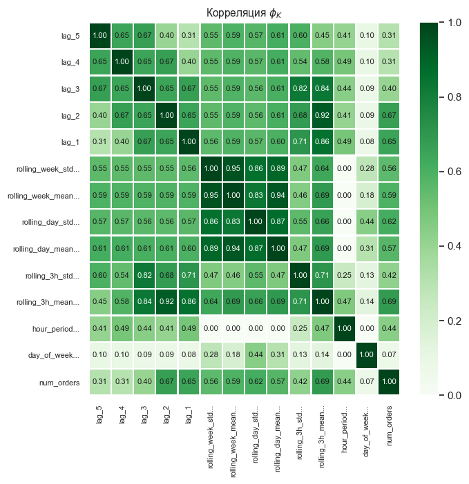

```python
phik_overview = df[col_phik_table].phik_matrix()
plot_correlation_matrix(phik_overview.values,
                        x_labels=phik_overview.columns,
                        y_labels=phik_overview.index,
                        vmin=0, vmax=1, color_map="Greens",
                        title=r"Корреляция $\phi_K$",
                        top=10,
                        print_both_numbers=False,
                        fontsize_factor=.8,
                        figsize=(7, 7))
plt.tight_layout()
```

Заметна высокая корреляция у следующих признаков:

- rolling_3h_mean
- rolling_3h_mean
- rolling_day_std
- rolling_week_std

При необходимости, это первые претенденты на исключение из обучающей выборки.

**Вывод**

В ходе анализа были добавлены признаки, рассмотрены тренд и сезонность, а так же определена стационарность временного ряда. Исследуя корреляцию $\phi_K$, определены признаки для возможного дальнейшего удаления.

Данные готовы для обучения модели.

К содержанию

## Обучение

### Создание выборок

```python
train, test = train_test_split(df, shuffle=False, test_size=0.1,
                               random_state=RANDOM_STATE)

target_name = 'num_orders'
X_train = train.drop(target_name, axis=1)
y_train = train[target_name]
X_test = test.drop(target_name, axis=1)
y_test = test[target_name]
```

```python
# Проверка размеров выборок
[display(_.shape) for _ in [X_train, y_train, X_test, y_test]]
# Проверка размера тестовой выборки
print(f'Размер тестовой выборки в долях: {len(y_test) / len(df):.2f}')
```

```
(3823, 32)
```

```
(3823,)
```

```
(425, 32)
```

```
(425,)
```

```
Размер тестовой выборки в долях: 0.10
```

Создание выборок прошло успешно. Создан требуемый размер тестовой выборки.

К содержанию

### Подготовка датасетов

```python
df.info()
```

```
<class 'pandas.core.frame.DataFrame'>
DatetimeIndex: 4248 entries, 2018-03-08 00:00:00 to 2018-08-31 23:00:00
Freq: H
Data columns (total 33 columns):
 #   Column             Non-Null Count  Dtype
---  ------             --------------  -----
 0   num_orders         4248 non-null   int64
 1   day_of_week        4248 non-null   int64
 2   hour_period        4248 non-null   object
 3   rolling_3h_mean    4248 non-null   float64
 4   rolling_3h_std     4248 non-null   float64
 5   rolling_day_mean   4248 non-null   float64
 6   rolling_day_std    4248 non-null   float64
 7   rolling_week_mean  4248 non-null   float64
 8   rolling_week_std   4248 non-null   float64
```

[output cut: 26 more lines]

```python
cat_mee_features = ['day_of_week', 'hour_period']
num_features = list(set(X_train.columns) - set(cat_mee_features))


# Масштабирование и кодирование
column_transformer = make_column_transformer((StandardScaler(), num_features),
                                             (MEstimateEncoder(), cat_mee_features),
                                             remainder='passthrough')
```

```python
column_transformer
```

```
ColumnTransformer(remainder='passthrough',
                  transformers=[('standardscaler', StandardScaler(),
                                 ['lag_21', 'rolling_week_mean', 'lag_9',
                                  'lag_18', 'lag_7', 'rolling_day_std',
                                  'lag_17', 'lag_12', 'lag_5', 'lag_1',
                                  'rolling_3h_mean', 'lag_2', 'lag_13',
                                  'rolling_day_mean', 'lag_19', 'lag_4',
                                  'lag_16', 'lag_20', 'lag_22', 'lag_14',
                                  'rolling_3h_std', 'lag_3', 'lag_6', 'lag_15',
                                  'lag_10', 'rolling_week_std', 'lag_23',
                                  'lag_24', 'lag_11', 'lag_8']),
                                ('mestimateencoder', MEstimateEncoder(),
                                 ['day_of_week', 'hour_period'])])
```

К содержанию

### Обучение моделей

```python
%%time

# Модели и параметры
models = [
    (LinearRegression(), {}),
    (DecisionTreeRegressor(), {
        'criterion': ['squared_error', 'friedman_mse'],
        'max_depth': list(range(4, 8)),
        'random_state': [RANDOM_STATE]
    }),
    (LGBMRegressor(), {
        'boosting_type': ['gbdt'],
        'n_estimators': [100],
        'max_depth': [5, 12],
        'verbose': [-1],
        'random_state': [RANDOM_STATE],
        'force_col_wise': [True],
        'num_leaves': [100, 130]
    }),

]

# Переменные
best_model = None
best_score = -10000
pipeline_models = []

# Разбиваем выборку для кросс-валидации
tscv = TimeSeriesSplit(n_splits = 24*7)


for model, param_grid in models:
    pipeline = make_pipeline(
        column_transformer,
        GridSearchCV(
            model,
            param_grid=param_grid,
            cv=tscv,
            scoring='neg_root_mean_squared_error',
            verbose=1
        )
    )
    pipeline.fit(X_train, y_train)
    pipeline_models.append(pipeline)

    if pipeline.named_steps['gridsearchcv'].best_score_ > best_score:
        best_score = pipeline.named_steps['gridsearchcv'].best_score_
        best_model = pipeline
```

```
Fitting 168 folds for each of 1 candidates, totalling 168 fits
Fitting 168 folds for each of 8 candidates, totalling 1344 fits
Fitting 168 folds for each of 4 candidates, totalling 672 fits
CPU times: total: 5min 18s
Wall time: 1min 33s
```

```python
# Сводная таблица по результатам обучения
def result_education(pipelines):
    # Получаем показатели из результатов обучения
    result_table = {}
    for pipeline_model in pipelines:
        grid = pipeline_model.named_steps['gridsearchcv']
        # Распаковка показателей
        test_score = []
        idx_best = grid.cv_results_['rank_test_score'].argmin()
        for res, val in grid.cv_results_.items():
            # Время обучения лучшей модели
            if res == 'mean_fit_time':
                mean_fit_time = val[idx_best]
            # Время предсказания лучшей модели
            elif res == 'mean_score_time':
                mean_score_time = val[idx_best]
            # RMSE лучшей модели
            elif 'split' in res:
                test_score.append(abs(val[idx_best]))

        result_table[str(grid.estimator)] = [mean_fit_time,
                                             mean_score_time,
                                             np.mean(test_score)]

    # Сводим нужные показатели в таблицу
    result_table = pd.DataFrame(result_table).T.reset_index()
    result_table.columns = ['Решатель', 'Время обучения (сек.)',
                            'Время предсказания (сек.)', 'RMSE']


    display(result_table)
```

```python
result_education(pipeline_models)
```

|  | Решатель | Время обучения (сек.) | Время предсказания (сек.) | RMSE |
| --- | --- | --- | --- | --- |
| 0 | LinearRegression() | 0.01 | 0.00 | 25.15 |
| 1 | DecisionTreeRegressor() | 0.01 | 0.00 | 26.95 |
| 2 | LGBMRegressor() | 0.05 | 0.00 | 22.64 |

```python
print('Лучшая модель:', best_model.named_steps['gridsearchcv'].best_estimator_)
print('Наилучшие параметры:', best_model.named_steps['gridsearchcv'].best_params_)
print('Лучшая оценка:', abs(best_score))
```

```
Лучшая модель: LGBMRegressor(force_col_wise=True, max_depth=5, num_leaves=100,
              random_state=RandomState(MT19937) at 0x1AA032A4640, verbose=-1)
Наилучшие параметры: {'boosting_type': 'gbdt', 'force_col_wise': True, 'max_depth': 5, 'n_estimators': 100, 'num_leaves': 100, 'random_state': RandomState(MT19937) at 0x1AA6238C240, 'verbose': -1}
Лучшая оценка: 22.63791910709848
```

К содержанию

### Удаление излишних признаков из обучающей выборки

```python
# Сочетания признаков для удаления
suspect_features = ['rolling_3h_mean', 'rolling_3h_std',
                    'rolling_week_mean', 'rolling_week_std']

def generate_combinations(elements):
    list_combinations = []
    for r in range(1, len(elements) + 1):
        list_combinations.extend(combinations(elements, r))

    # Убрать дубликаты комбинаций
    unique_combinations = list(set(list_combinations))

    return unique_combinations


all_combinations = generate_combinations(suspect_features)

# Ищем комбинации признаков для удаления и обновляем лучшую модель
best_combination = []
pipeline_models_features = []

for idx, combination in enumerate(all_combinations):
    cat_mee_features = ['day_of_week', 'hour_period']
    num_features = list(set(X_train.columns)
                        - set(combination)
                        - set(cat_mee_features))

    print(f'Номер комбинации признаков: {idx + 1} из {len(all_combinations)}')

    # Масштабирование и кодирование
    column_transformer = make_column_transformer(
        (StandardScaler(), num_features),
        (MEstimateEncoder(), cat_mee_features),
        remainder='passthrough')

    pipeline = make_pipeline(
        column_transformer,
        GridSearchCV(
            LGBMRegressor(),
            param_grid={
                'boosting_type': ['gbdt'],
                'n_estimators': [100],
                'max_depth': [5],
                'verbose': [-1],
                'random_state': [RANDOM_STATE],
                'force_col_wise': [True],
                'num_leaves': [100]
            },
            cv=tscv,
            scoring='neg_root_mean_squared_error',
            verbose=1
        )
    )
    pipeline.fit(X_train, y_train)
    pipeline_models_features.append(pipeline)

    if pipeline.named_steps['gridsearchcv'].best_score_ > best_score:
        best_score = pipeline.named_steps['gridsearchcv'].best_score_
        best_model = pipeline
        best_combination = combination
```

```
Номер комбинации признаков: 1 из 15
Fitting 168 folds for each of 1 candidates, totalling 168 fits
Номер комбинации признаков: 2 из 15
Fitting 168 folds for each of 1 candidates, totalling 168 fits
Номер комбинации признаков: 3 из 15
Fitting 168 folds for each of 1 candidates, totalling 168 fits
Номер комбинации признаков: 4 из 15
Fitting 168 folds for each of 1 candidates, totalling 168 fits
Номер комбинации признаков: 5 из 15
Fitting 168 folds for each of 1 candidates, totalling 168 fits
Номер комбинации признаков: 6 из 15
Fitting 168 folds for each of 1 candidates, totalling 168 fits
Номер комбинации признаков: 7 из 15
Fitting 168 folds for each of 1 candidates, totalling 168 fits
Номер комбинации признаков: 8 из 15
Fitting 168 folds for each of 1 candidates, totalling 168 fits
Номер комбинации признаков: 9 из 15
Fitting 168 folds for each of 1 candidates, totalling 168 fits
Номер комбинации признаков: 10 из 15
Fitting 168 folds for each of 1 candidates, totalling 168 fits
Номер комбинации признаков: 11 из 15
Fitting 168 folds for each of 1 candidates, totalling 168 fits
Номер комбинации признаков: 12 из 15
Fitting 168 folds for each of 1 candidates, totalling 168 fits
Номер комбинации признаков: 13 из 15
Fitting 168 folds for each of 1 candidates, totalling 168 fits
Номер комбинации признаков: 14 из 15
Fitting 168 folds for each of 1 candidates, totalling 168 fits
Номер комбинации признаков: 15 из 15
Fitting 168 folds for each of 1 candidates, totalling 168 fits
```

```python
result_education(pipeline_models_features)
```

|  | Решатель | Время обучения (сек.) | Время предсказания (сек.) | RMSE |
| --- | --- | --- | --- | --- |
| 0 | LGBMRegressor() | 0.05 | 0.00 | 22.64 |

```python
best_combination
```

```
('rolling_week_mean',)
```

К содержанию

## Тестирование

```python
# Оценщик RMSE для тестирования
def rmse(y_true, y_pred, **kwargs):
    return mean_squared_error(y_true, y_pred, squared=False)
```

```python
y_pred = best_model.predict(X_test)
rmse_test = rmse(y_test, y_pred)

print(f'RMSE на тестовой выборке: {rmse_test:.2f}')
if rmse_test < 48:
    print('RMSE меньше 48, требуемое качество модели достигнуто')
else:
    print('RMSE не меньше 48, требуемое качество модели не достигнуто')
```

```
RMSE на тестовой выборке: 41.26
RMSE меньше 48, требуемое качество модели достигнуто
```

К содержанию

### Проверка модели на адекватность

```python
# Генерация результата простой модели
y_pred_const = y_test.shift().fillna(0)
rmse_test_const = rmse(y_test, y_pred_const)

print(f'RMSE константной модели на тестовой выборке: {rmse_test_const:.2f}')
if rmse_test < rmse_test_const:
    print('RMSE на тестовой выборке меньше, чем RMSE константной модели - '
          'тест пройден')
else:
    print('RMSE на тестовой выборке больше, чем RMSE константной модели - '
          'тест не пройден')
```

```
RMSE константной модели на тестовой выборке: 58.88
RMSE на тестовой выборке меньше, чем RMSE константной модели - тест пройден
```

К содержанию

## Вывод

Для компании "Чётенькое такси" была разработана эффективная модель прогнозирования количества заказов такси на следующий час, основанная на анализе исторических данных о заказах такси в аэропортах.

Основной моделью, которая демонстрировала желаемый уровень точности согласно метрике RMSE на тестовой выборке: 41.26, оказалась "LGBMRegressor".

## Чек-лист проверки

- Jupyter Notebook открыт
- Весь код выполняется без ошибок
- Ячейки с кодом расположены в порядке исполнения
- Данные загружены и подготовлены
- Данные проанализированы
- Модель обучена, гиперпараметры подобраны
- Качество моделей проверено, выводы сделаны
- Значение *RMSE* на тестовой выборке не больше 48